# Accessibilité des espaces verts par commune via le réseau routier

- Montrer tout le code
- Cacher tout le code
- Voir les sources

Green Acess toolbox — Python pour ArcGIS Pro

Auteur·rice

Affiliation

Djibril SOUMARE

Université Paris 8 Vincennes – Saint-Denis

Date de publication

9 mars 2026

# 1 Introduction

**Note**

Ce rapport présente la résolution de l’évaluation finale du cours *Python pour ArcGIS Pro* du Master 2 G2M de l’Université Paris 8 Vincennes – Saint-Denis. L’exercice porte sur la conception d’un outil de géotraitement complet (GP Tool) permettant d’analyser l’accessibilité des espaces verts par commune via le réseau routier, en s’appuyant sur un processus guidé par un **prompt d’intelligence artificielle**.

Le travail est structuré en deux parties correspondant aux deux volets de l’évaluation :

1. Rédaction d’un prompt structuré et précis destiné à un modèle d’IA pour générer automatiquement le code Python du GP Tool
2. Construction de la toolbox ArcGIS Pro (`.atbx`) et intégration du script Python généré

# 2 Contexte métier et données

## 2.1 Problématique

La Ville de Paris souhaite identifier les communes présentant une faible accessibilité aux espaces verts ou une forte pression sur les infrastructures routières. L’analyse doit répondre à la question suivante :

> **Quelle est la longueur de routes par commune situées à moins de X mètres d’un espace vert ?**

Ce résultat permet d’estimer la desserte des parcs, la pression urbaine autour des espaces verts et les zones prioritaires d’aménagement.

## 2.2 Données du fichier `green_access.gdb`

Le fichier GeoDataBase contient 3 couches :

| Couche | Géométrie | Description |
| --- | --- | --- |
| `communes` | Polygone | Limites communales (champ `INSEE_COM` ou `NOM_COM`) |
| `espaces_verts` | Polygone | Parcs et jardins publics |
| `routes` | Ligne | Réseau viaire |

Les données sources sont en WGS84 (EPSG:4326). Une reprojection en Lambert-93 (EPSG:2154) est nécessaire pour effectuer des calculs de distance et de longueur en mètres.

# 3 Partie 1 : Conception du prompt IA

**Démarche**

La première partie de l’évaluation consiste à démontrer la capacité à structurer un besoin technique complexe et à le traduire en instructions précises pour un modèle d’IA. Un prompt de qualité doit permettre à l’IA de générer directement un code fonctionnel, sans ambiguïté.

Le prompt est organisé en plusieurs sections distinctes : définition du rôle de l’IA, description des données sources, spécification des paramètres de l’outil, structure imposée du script, détail du workflow de géotraitement et contraintes techniques.

## 3.1 Rôle et objectif assignés à l’IA

Le prompt commence par définir explicitement le rôle de l’IA (*« expert en développement Python ArcGIS Pro »*) et l’objectif global de l’outil. Cette approche de *roleplay* améliore la cohérence et la précision des réponses générées.

## 3.2 Paramètres du Script Tool

Un tableau structuré définit les 6 paramètres attendus, avec leur type ArcGIS, leur caractère obligatoire et leur description :

| N° | Paramètre | Type ArcGIS | Obligatoire | Description |
| --- | --- | --- | --- | --- |
| 0 | `communes` | Feature Layer (Polygon) | Oui | Couche des communes |
| 1 | `espaces_verts` | Feature Layer (Polygon) | Oui | Couche des espaces verts |
| 2 | `routes` | Feature Layer (Line) | Oui | Couche du réseau routier |
| 3 | `distance_buffer` | Double | Oui | Distance tampon en mètres (ex. : 300) |
| 4 | `output_fc` | Feature Class (sortie) | Oui | Couche communes enrichie en sortie |
| 5 | `workspace` | Workspace | Oui | GDB de travail pour les fichiers intermédiaires |

## 3.3 Structure imposée du script

Le prompt impose une architecture en 4 blocs commentés, exécutés séquentiellement (sans classe ni fonction `main()`). Cette structure garantit la lisibilité et la maintenabilité du code généré :

```python
import arcpy
import os

# =========================
# RÉCUPÉRATION DES PARAMÈTRES
# =========================

# =========================
# VALIDATIONS AVANT TRAITEMENT
# =========================

# =========================
# EXÉCUTION DU TRAITEMENT
# =========================
try:
    pass  # étapes de géotraitement avec arcpy.AddMessage()

# =========================
# GESTION DES ERREURS
# =========================
except arcpy.ExecuteError:
    arcpy.AddError(arcpy.GetMessages(2))
except Exception as e:
    arcpy.AddError(str(e))
```

## 3.4 Workflow de géotraitement spécifié

**ImportantPrincipales étapes**

1. Buffer de `distance_buffer` mètres autour des espaces verts → `arcpy.analysis.Buffer`
2. Clip des routes par le buffer → `arcpy.analysis.Clip`
3. Intersection routes / communes → `arcpy.analysis.Intersect`
4. Ajout du champ `LONGUEUR_M` et calcul → `arcpy.management.CalculateGeometryAttributes`
5. Statistiques de somme par commune → `arcpy.analysis.Statistics`
6. Copie des communes vers la sortie → `arcpy.management.CopyFeatures`
7. Jointure des statistiques → `arcpy.management.JoinField`
8. Remplacement des valeurs nulles par `0` → `UpdateCursor`
9. Suppression des fichiers temporaires → `arcpy.management.Delete`

**Points clés**

- La **définition explicite du rôle** de l’IA (*roleplay*) améliore la cohérence du code généré.
- La **spécification des noms exacts** des fonctions ArcPy évite les approximations et les erreurs d’API.
- La **structure en 4 blocs imposée** garantit un code directement lisible et intégrable dans une toolbox.
- Les **contraintes techniques** (préfixe `_tmp_`, commentaires en français, pas de `if __name__ == "__main__":`) assurent la conformité aux attentes pédagogiques.

# 4 Partie 2 : Construction de la toolbox ArcGIS Pro

**Démarche**

La deuxième partie consiste à créer une toolbox ArcGIS Pro (`.atbx`), à y intégrer un Script Tool avec ses paramètres correctement configurés, puis à y associer le script Python généré.

## 4.1 Création de la toolbox

La toolbox `green_acess_tools.atbx` a été créée dans le dossier `commondata` du projet `evaluation_finale_package`. Elle est visible dans le panneau Catalogue d’ArcGIS Pro, aux côtés de la GDB et des autres ressources du projet.

[figure not shown]

Toolbox `green_acess_tools.atbx` dans le panneau Catalogue d’ArcGIS Pro

## 4.2 Métadonnées et syntaxe de l’outil

L’outil **greencesstools** créé au sein de la toolbox dispose d’une description explicite et d’une syntaxe documentée avec l’ensemble de ses paramètres, visibles dans les métadonnées ArcGIS Pro.

[figure not shown]

Métadonnées de l’outil : description, syntaxe et liste des paramètres

## 4.3 Propriétés générales

La fenêtre de propriétés (onglet **Général**) présente le nom de l’outil, son étiquette, le chemin de la toolbox et la description. Ces métadonnées sont essentielles pour la documentation et la maintenabilité de l’outil.

[figure not shown]

Propriétés générales de l’outil : nom, étiquette, chemin et description

## 4.4 Configuration des paramètres

L’onglet **Paramètres** montre la configuration des 6 paramètres. Chaque paramètre est correctement typé, obligatoire, et orienté (Entrée/Sortie). Des filtres de type d’entités sont appliqués aux couches `communes`, `espaces_verts` et `routes` pour guider l’utilisateur lors de la saisie.

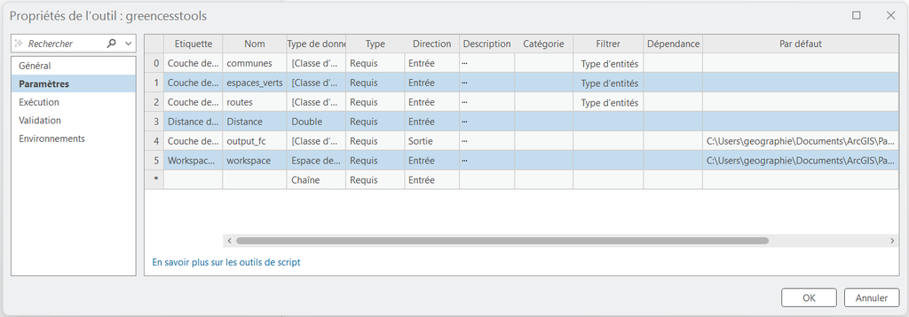

Configuration des 6 paramètres dans l’onglet Paramètres

## 4.5 Intégration du script Python

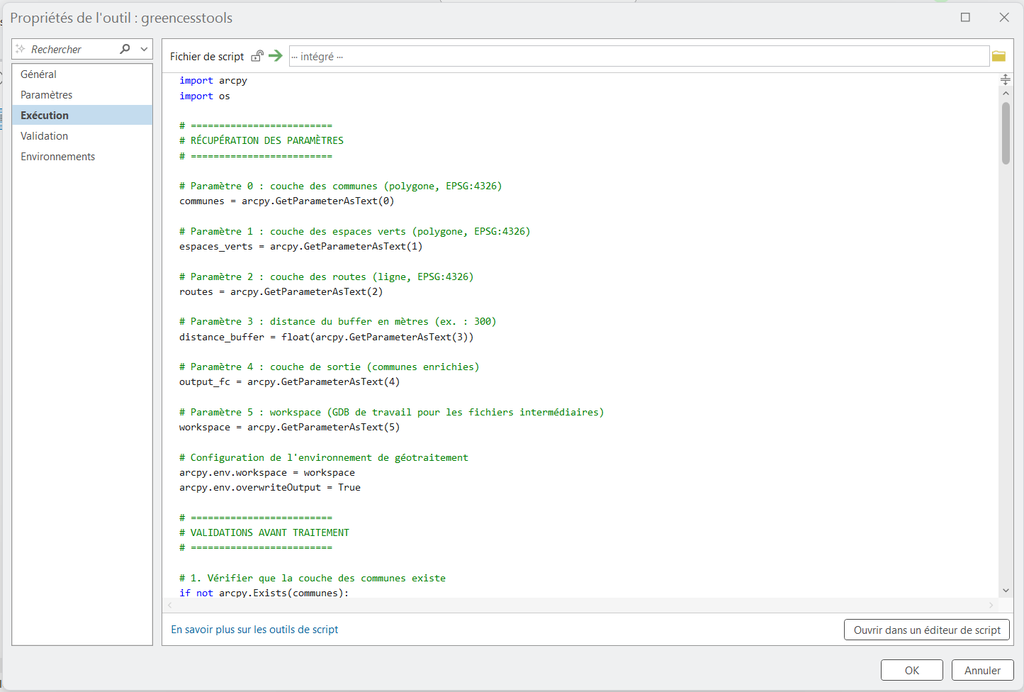

Script Python intégré dans l’onglet Exécution de l’outil

**Points clés**

- La toolbox `.atbx` est **correctement structurée** et référencée dans le projet ArcGIS Pro.
- Les **6 paramètres** sont tous typés, obligatoires et accompagnés d’une description.
- Les **filtres de type d’entités** (polygone pour communes et espaces verts, ligne pour routes) empêchent les erreurs de saisie.
- Le script est **embarqué directement** dans l’outil, ce qui facilite la distribution du package.

# 5 Analyse du script Python

## 5.1 Récupération des paramètres

Les 6 paramètres sont récupérés via `arcpy.GetParameterAsText()`. La distance est convertie en `float` pour les calculs numériques. L’environnement de géotraitement est configuré dans ce même bloc.

```python
# Paramètre 0 : couche des communes (polygone, EPSG:4326)
communes = arcpy.GetParameterAsText(0)

# Paramètre 1 : couche des espaces verts (polygone, EPSG:4326)
espaces_verts = arcpy.GetParameterAsText(1)

# Paramètre 2 : couche des routes (ligne, EPSG:4326)
routes = arcpy.GetParameterAsText(2)

# Paramètre 3 : distance du buffer en mètres (ex. : 300)
distance_buffer = float(arcpy.GetParameterAsText(3))

# Paramètre 4 : couche de sortie (communes enrichies)
output_fc = arcpy.GetParameterAsText(4)

# Paramètre 5 : workspace (GDB de travail)
workspace = arcpy.GetParameterAsText(5)

# Configuration de l'environnement
arcpy.env.workspace = workspace
arcpy.env.overwriteOutput = True
```

## 5.2 Validations avant traitement

Le script effectue **6 vérifications préalables** avant d’entrer dans le bloc `try`. Cette approche garantit un arrêt propre avec un message d’erreur explicite en cas de données manquantes ou de paramètres incorrects.

```python
if not arcpy.Exists(communes):
    arcpy.AddError("La couche 'communes' n'existe pas ou le chemin est incorrect.")
    raise SystemExit

if not arcpy.Exists(espaces_verts):
    arcpy.AddError("La couche 'espaces_verts' n'existe pas ou le chemin est incorrect.")
    raise SystemExit

if not arcpy.Exists(routes):
    arcpy.AddError("La couche 'routes' n'existe pas ou le chemin est incorrect.")
    raise SystemExit

if distance_buffer <= 0:
    arcpy.AddError("La distance du buffer doit être strictement supérieure à 0.")
    raise SystemExit

if arcpy.Exists(output_fc):
    arcpy.AddError("La couche de sortie existe déjà. Veuillez choisir un autre nom.")
    raise SystemExit

if not arcpy.Exists(workspace):
    arcpy.AddError("Le workspace spécifié n'existe pas ou n'est pas accessible.")
    raise SystemExit
```

## 5.3 Reprojection en Lambert-93

La reprojection systématique des trois couches en Lambert-93 (EPSG:2154) est indispensable avant tout calcul. Les données sources étant en WGS84 (degrés décimaux), les distances et longueurs ne peuvent pas être calculées en mètres sans cette étape préalable. Lambert-93 est la projection métrique officielle pour la France métropolitaine.

```python
arcpy.AddMessage("Étape 1/9 — Reprojection des données vers Lambert 93 (EPSG:2154)...")
sr_lambert93 = arcpy.SpatialReference(2154)

arcpy.management.Project(communes,      tmp_communes_proj, sr_lambert93)
arcpy.management.Project(espaces_verts, tmp_ev_proj,       sr_lambert93)
arcpy.management.Project(routes,        tmp_routes_proj,   sr_lambert93)
```

## 5.4 Géotraitement principal

Les étapes de géotraitement s’enchaînent dans le bloc `try`. Le buffer est créé avec l’option `dissolve_option="ALL"` pour fusionner tous les espaces verts en une seule zone tampon avant le découpage des routes.

```python
# Étape 2 : Buffer autour des espaces verts
arcpy.AddMessage("Étape 2/9 — Création du buffer autour des espaces verts...")
arcpy.analysis.Buffer(
    in_features=tmp_ev_proj,
    out_feature_class=tmp_buffer_ev,
    buffer_distance_or_field=f"{distance_buffer} Meters",
    dissolve_option="ALL"
)

# Étape 3 : Clip des routes par le buffer
arcpy.AddMessage("Étape 3/9 — Découpage des routes par la zone tampon...")
arcpy.analysis.Clip(
    in_features=tmp_routes_proj,
    clip_features=tmp_buffer_ev,
    out_feature_class=tmp_routes_clip
)

# Étape 4 : Intersection routes / communes
arcpy.AddMessage("Étape 4/9 — Intersection des routes avec les communes...")
arcpy.analysis.Intersect(
    in_features=[tmp_routes_clip, tmp_communes_proj],
    out_feature_class=tmp_routes_communes,
    join_attributes="ALL"
)
```

## 5.5 Calcul des longueurs et statistiques

Le champ `LONGUEUR_M` est recalculé **après** le Clip et l’Intersect, car la longueur originale des tronçons dans la couche source ne correspond plus à la longueur réelle des segments découpés.

```python
# Étape 5 : Calcul de la longueur réelle en mètres
arcpy.AddMessage("Étape 5/9 — Calcul des longueurs réelles (en mètres)...")
arcpy.management.AddField(tmp_routes_communes, "LONGUEUR_M", "DOUBLE")
arcpy.management.CalculateGeometryAttributes(
    in_features=tmp_routes_communes,
    geometry_property=[["LONGUEUR_M", "LENGTH"]],
    length_unit="METERS"
)

# Étape 6 : Statistiques — somme par commune
arcpy.AddMessage("Étape 6/9 — Agrégation des longueurs par commune...")

# Détection automatique du champ identifiant commune
champs = [f.name for f in arcpy.ListFields(tmp_routes_communes)]
champ_commune = None
for candidat in ["insee", "C_COINSEE", "INSEE_COM", "NOM_COM", "nom"]:
    if candidat in champs:
        champ_commune = candidat
        break

if champ_commune is None:
    arcpy.AddError("Aucun champ identifiant commune trouvé.")
    raise SystemExit

arcpy.analysis.Statistics(
    in_table=tmp_routes_communes,
    out_table=tmp_stats,
    statistics_fields=[["LONGUEUR_M", "SUM"]],
    case_field=champ_commune
)
```

## 5.6 Jointure et traitement des valeurs nulles

Après la jointure des statistiques sur la couche des communes, les communes sans aucune route dans la zone tampon n’ont pas de correspondance dans la table de statistiques. Leur valeur `SUM_LONGUEUR_M` est `NULL` après la jointure et remplacée par `0` via un `UpdateCursor`.

```python
# Étape 7 : Copie des communes vers la sortie
arcpy.AddMessage("Étape 7/9 — Copie de la couche communes vers la sortie...")
arcpy.management.CopyFeatures(tmp_communes_proj, output_fc)

# Étape 8 : Jointure des statistiques
arcpy.AddMessage("Étape 8/9 — Jointure des statistiques sur la couche communes...")
arcpy.management.JoinField(
    in_data=output_fc,
    in_field=champ_commune,
    join_table=tmp_stats,
    join_field=champ_commune,
    fields=["SUM_LONGUEUR_M"]
)

# Étape 9 : Remplacement des valeurs nulles par 0
arcpy.AddMessage("Étape 9/9 — Remplacement des valeurs nulles par 0...")
with arcpy.da.UpdateCursor(output_fc, ["SUM_LONGUEUR_M"]) as cursor:
    for row in cursor:
        if row[0] is None:
            row[0] = 0
            cursor.updateRow(row)
```

## 5.7 Nettoyage des fichiers intermédiaires

L’ensemble des 7 couches temporaires (préfixées `_tmp_`) est supprimé en fin de traitement. Cette bonne pratique évite l’accumulation de données dans la GDB de travail.

```python
for tmp in [tmp_communes_proj, tmp_ev_proj, tmp_routes_proj,
            tmp_buffer_ev, tmp_routes_clip, tmp_routes_communes, tmp_stats]:
    if arcpy.Exists(tmp):
        arcpy.management.Delete(tmp)

arcpy.AddMessage("Traitement terminé avec succès.")
arcpy.AddMessage(f"Résultat disponible dans : {output_fc}")
arcpy.AddMessage("Projection de sortie : RGF93 / Lambert-93 (EPSG:2154)")
```

# 6 Conclusion

Ce projet d’évaluation a permis de mettre en pratique l’ensemble du cycle de développement d’un outil de géotraitement ArcGIS Pro : formalisation du besoin métier, rédaction d’un prompt structuré, génération et adaptation du code Python, création et configuration d’une toolbox, et intégration du script.

Les deux parties forment une progression cohérente : de la conception du prompt (partie 1) à la mise en œuvre technique dans ArcGIS Pro (partie 2), illustrant comment une approche guidée par IA peut accélérer le développement d’outils SIG tout en maintenant une qualité de code élevée.

L’outil **greencesstools** répond pleinement à la problématique initiale : il calcule, pour chaque commune, la longueur totale des routes situées à moins d’une distance paramétrable d’un espace vert, et produit une couche enrichie prête à être cartographiée ou analysée statistiquement dans ArcGIS Pro.

# 7 Références et sources des données

- **Anthropic** (2025). Claude — Modèle d’IA utilisé pour la génération du code Python via prompt structuré. https://www.anthropic.com/
- **ESRI** (2024). ArcGIS Pro 3.x — Logiciel de SIG et environnement de développement ArcPy. https://pro.arcgis.com/
- **ESRI** (2024). ArcPy Site Package — Documentation de référence de l’API Python pour ArcGIS. https://pro.arcgis.com/en/pro-app/latest/arcpy/main/arcgis-pro-arcpy-reference.htm
- **IGN** (2021). BD CARTO® — Base de données cartographiques de l’Institut national de l’information géographique et forestière.
- Pimpler, E. (2017). *Programming ArcGIS Pro with Python*. Packt Publishing.
- Beroud A. (2025). Supports de cours — Python pour ArcGIS Pro, Séance 5. Master 2 G2M, Université Paris 8.